# Analysis of Washington DC Metro Area Capital Bikeshare 2021

## Introduction

Capital Bikeshare (also abbreviated CaBi) is a bicycle-sharing system which serves Washington, D.C.; Arlington County, Virginia; the cities of Alexandria, Virginia and Falls Church, Virginia; Montgomery County, Maryland and Fairfax County, Virginia. As of May 2021, it had 627 stations and 5,400+ bicycles, all owned by these local governments and operated by contractor Motivate International. Opened in September 2010, the system was the largest bike sharing service in the United States until New York City's Citi Bike began operations in May 2013.

## Preliminary Wrangling

```python
# import necessary packages and set plots to be embedded inline
import numpy as np
import pandas as pd
import seaborn as sns
import matplotlib as mpl
import matplotlib.pyplot as plt
import glob
import os
import datetime

%matplotlib inline
```

```python
# dir path to dataset to use for analysis
for name in glob.glob('city bikeshare/*tripdata.csv'):
    print(name)
```

```
city bikeshare\202101-capitalbikeshare-tripdata.csv
city bikeshare\202102-capitalbikeshare-tripdata.csv
city bikeshare\202103-capitalbikeshare-tripdata.csv
city bikeshare\202104-capitalbikeshare-tripdata.csv
city bikeshare\202105-capitalbikeshare-tripdata.csv
city bikeshare\202106-capitalbikeshare-tripdata.csv
city bikeshare\202107-capitalbikeshare-tripdata.csv
city bikeshare\202108-capitalbikeshare-tripdata.csv
city bikeshare\202109-capitalbikeshare-tripdata.csv
city bikeshare\202110-capitalbikeshare-tripdata.csv
city bikeshare\202111-capitalbikeshare-tripdata.csv
city bikeshare\202112-capitalbikeshare-tripdata.csv
```

```python
csv_files = glob.glob('capital bikeshare/*tripdata.csv')

# Read each CSV file into DataFrame
# This creates a list of dataframes
df_list = (pd.read_csv(file, low_memory=False) for file in csv_files)

# Concatenate all DataFrames
big_df   = pd.concat(df_list, ignore_index=True)
```

```python
## save concatenated dataframes
big_df.to_csv('capital_bikeshare_master.csv',index=False)
```

## Assess

```python
#load saved dataset
df = pd.read_csv('capital_bikeshare_master.csv', low_memory=False)
```

```python
# first 5 roles
df.head()
```

|  | ride_id | rideable_type | started_at | ended_at | start_station_name | start_station_id | end_station_name | end_station_id | start_lat | start_lng | end_lat | end_lng | member_casual |
| --- | --- | --- | --- | --- | --- | --- | --- | --- | --- | --- | --- | --- | --- |
| 0 | 13A48BD20CC3DD85 | classic_bike | 2021-01-08 17:58:48 | 2021-01-08 18:25:23 | Connecticut Ave & Yuma St NW | 31318.0 | Georgia Ave & Emerson St NW | 31405.0 | 38.947156 | -77.065115 | 38.949662 | -77.027333 | casual |
| 1 | CA68C580B32EEE66 | electric_bike | 2021-01-08 22:05:51 | 2021-01-08 22:23:52 | 8th & D St NW | 31270.0 | 14th & D St SE | 31663.0 | 38.894804 | -77.023091 | 38.884053 | -76.986043 | member |
| 2 | 5A925307814D5C2B | classic_bike | 2021-01-21 17:20:31 | 2021-01-21 17:23:24 | Wilson Blvd. & N. Vermont St. | 31926.0 | George Mason Dr & Wilson Blvd | 31036.0 | 38.879477 | -77.114563 | 38.878870 | -77.120700 | member |
| 3 | B6B2DB54A2B233EE | classic_bike | 2021-01-28 10:06:30 | 2021-01-28 10:20:54 | Franklin St & S Washington St | 31907.0 | Braddock Rd Metro | 31047.0 | 38.798133 | -77.048700 | 38.814577 | -77.052808 | member |
| 4 | 921A142D5C8A9759 | classic_bike | 2021-01-11 12:09:45 | 2021-01-11 12:20:15 | St. Asaph & Montgomery St | 31931.0 | Braddock Rd Metro | 31047.0 | 38.814185 | -77.043809 | 38.814577 | -77.052808 | casual |

```python
# for dataset data types and summary info
df.info(show_counts=True)
```

```
<class 'pandas.core.frame.DataFrame'>
RangeIndex: 2749881 entries, 0 to 2749880
Data columns (total 13 columns):
 #   Column              Non-Null Count    Dtype
---  ------              --------------    -----
 0   ride_id             2749881 non-null  object
 1   rideable_type       2749881 non-null  object
 2   started_at          2749881 non-null  object
 3   ended_at            2749881 non-null  object
 4   start_station_name  2553555 non-null  object
 5   start_station_id    2553555 non-null  object
 6   end_station_name    2530622 non-null  object
 7   end_station_id      2530622 non-null  object
 8   start_lat           2749879 non-null  float64
 9   start_lng           2749879 non-null  float64
 10  end_lat             2745078 non-null  float64
 11  end_lng             2745078 non-null  float64
 12  member_casual       2749881 non-null  object
dtypes: float64(4), object(9)
memory usage: 272.7+ MB
```

Some of the column data types are incorrect, hence some cleaning will be done

```python
# check for row duplicates
df.duplicated().sum()
```

```
0
```

```python
# percentage of null values to each column rows
df.isnull().mean()*100
```

```
ride_id               0.000000
rideable_type         0.000000
started_at            0.000000
ended_at              0.000000
start_station_name    7.139436
start_station_id      7.139436
end_station_name      7.973400
end_station_id        7.973400
start_lat             0.000073
start_lng             0.000073
end_lat               0.174662
end_lng               0.174662
member_casual         0.000000
dtype: float64
```

summary of data qualities spotted

1. `rideable_type` column
- data type should be **category** not object
- values seperated by an **underscore**
1. `started_at` and `ended_at` column data types as **object**
1. `member_casual`
- data types in **object**
- column name should be change to **user_type**
1. Presence of null values

## Clean

```python
#copy of df before cleaning
df_clean = df.copy()
```

#### Define

- replace underscore with an empty space ' ' in `rideable_type`
- change `member_casual` column name to `user_type`
- drop all NaN values in the dataframe

#### Code

```python
# replace underscore with an empty string
df_clean.rideable_type = df_clean.rideable_type.str.replace('_', ' ')

#change column name
df_clean.rename(columns={'member_casual':'user_type'}, inplace=True)

#drop NaN values in dataframe
df_clean.dropna(inplace=True)
```

#### Test

```python
df_clean.head()
```

|  | ride_id | rideable_type | started_at | ended_at | start_station_name | start_station_id | end_station_name | end_station_id | start_lat | start_lng | end_lat | end_lng | user_type |
| --- | --- | --- | --- | --- | --- | --- | --- | --- | --- | --- | --- | --- | --- |
| 0 | 13A48BD20CC3DD85 | classic bike | 2021-01-08 17:58:48 | 2021-01-08 18:25:23 | Connecticut Ave & Yuma St NW | 31318.0 | Georgia Ave & Emerson St NW | 31405.0 | 38.947156 | -77.065115 | 38.949662 | -77.027333 | casual |
| 1 | CA68C580B32EEE66 | electric bike | 2021-01-08 22:05:51 | 2021-01-08 22:23:52 | 8th & D St NW | 31270.0 | 14th & D St SE | 31663.0 | 38.894804 | -77.023091 | 38.884053 | -76.986043 | member |
| 2 | 5A925307814D5C2B | classic bike | 2021-01-21 17:20:31 | 2021-01-21 17:23:24 | Wilson Blvd. & N. Vermont St. | 31926.0 | George Mason Dr & Wilson Blvd | 31036.0 | 38.879477 | -77.114563 | 38.878870 | -77.120700 | member |
| 3 | B6B2DB54A2B233EE | classic bike | 2021-01-28 10:06:30 | 2021-01-28 10:20:54 | Franklin St & S Washington St | 31907.0 | Braddock Rd Metro | 31047.0 | 38.798133 | -77.048700 | 38.814577 | -77.052808 | member |
| 4 | 921A142D5C8A9759 | classic bike | 2021-01-11 12:09:45 | 2021-01-11 12:20:15 | St. Asaph & Montgomery St | 31931.0 | Braddock Rd Metro | 31047.0 | 38.814185 | -77.043809 | 38.814577 | -77.052808 | casual |

#### Define

Correct data types should be assigned to respective columns

#### Code

```python
dtypes = {'rideable_type':'category',
         'user_type': 'category',
         'started_at': 'datetime64',
         'ended_at':'datetime64'}

df_clean = df_clean.astype(dtypes)
```

#### Test

```python
df_clean.info()
```

```
<class 'pandas.core.frame.DataFrame'>
Int64Index: 2454503 entries, 0 to 2749880
Data columns (total 13 columns):
 #   Column              Dtype
---  ------              -----
 0   ride_id             object
 1   rideable_type       category
 2   started_at          datetime64[ns]
 3   ended_at            datetime64[ns]
 4   start_station_name  object
 5   start_station_id    object
 6   end_station_name    object
 7   end_station_id      object
 8   start_lat           float64
 9   start_lng           float64
 10  end_lat             float64
 11  end_lng             float64
 12  user_type           category
dtypes: category(2), datetime64[ns](2), float64(4), object(5)
memory usage: 229.4+ MB
```

Enhance cleaned dataset to further create new columns vital for analysis

#### Code

```python
# creat a new column 'month name' from 'started_at' column
df_clean['started_month_name'] = df_clean['started_at'].dt.month_name()
```

```python
# weekday from 'started at' column
df_clean['started_weekday'] = df_clean['started_at'].dt.day_name()
```

```python
# day from 'started_at' column
df_clean['started_day'] = df_clean['started_at'].dt.day
```

```python
# hour from 'started_at' column
df_clean['started_hour'] = df_clean['started_at'].dt.hour
```

```python
# trip duration in seconds
df_clean['duration_sec'] = (df_clean['ended_at'] - df_clean['started_at']).dt.total_seconds()
```

#### Test

```python
df_clean.head()
```

|  | ride_id | rideable_type | started_at | ended_at | start_station_name | start_station_id | end_station_name | end_station_id | start_lat | start_lng | end_lat | end_lng | user_type | started_month_name | started_weekday | started_day | started_hour | duration_sec |
| --- | --- | --- | --- | --- | --- | --- | --- | --- | --- | --- | --- | --- | --- | --- | --- | --- | --- | --- |
| 0 | 13A48BD20CC3DD85 | classic bike | 2021-01-08 17:58:48 | 2021-01-08 18:25:23 | Connecticut Ave & Yuma St NW | 31318.0 | Georgia Ave & Emerson St NW | 31405.0 | 38.947156 | -77.065115 | 38.949662 | -77.027333 | casual | January | Friday | 8 | 17 | 1595.0 |
| 1 | CA68C580B32EEE66 | electric bike | 2021-01-08 22:05:51 | 2021-01-08 22:23:52 | 8th & D St NW | 31270.0 | 14th & D St SE | 31663.0 | 38.894804 | -77.023091 | 38.884053 | -76.986043 | member | January | Friday | 8 | 22 | 1081.0 |
| 2 | 5A925307814D5C2B | classic bike | 2021-01-21 17:20:31 | 2021-01-21 17:23:24 | Wilson Blvd. & N. Vermont St. | 31926.0 | George Mason Dr & Wilson Blvd | 31036.0 | 38.879477 | -77.114563 | 38.878870 | -77.120700 | member | January | Thursday | 21 | 17 | 173.0 |
| 3 | B6B2DB54A2B233EE | classic bike | 2021-01-28 10:06:30 | 2021-01-28 10:20:54 | Franklin St & S Washington St | 31907.0 | Braddock Rd Metro | 31047.0 | 38.798133 | -77.048700 | 38.814577 | -77.052808 | member | January | Thursday | 28 | 10 | 864.0 |
| 4 | 921A142D5C8A9759 | classic bike | 2021-01-11 12:09:45 | 2021-01-11 12:20:15 | St. Asaph & Montgomery St | 31931.0 | Braddock Rd Metro | 31047.0 | 38.814185 | -77.043809 | 38.814577 | -77.052808 | casual | January | Monday | 11 | 12 | 630.0 |

```python
# checking 'duration_sec' column for any anomalities
print('Shortest bike ride in seconds :',df_clean['duration_sec'].min())
print('Longest bike ride in seconds :',df_clean['duration_sec'].max())
```

```
Shortest bike ride in seconds : -3313.0
Longest bike ride in seconds : 3272428.0
```

From the minimum bike ride in seconds, there seeem to be a negative sign, this should'nt be possible as the expected output to get from a datetime should be positive. A further assessment will be carried to know why there are negative values from the timestamp difference output

```python
# first convert 'duration_sec' datatype to str so as to manipulate the values easily
df_clean['duration_sec'] = df_clean['duration_sec'].astype(str)
```

```python
# extract only rows that contains negative
filter_ = df_clean.loc[df_clean['duration_sec'].str.contains('-')][['started_at','ended_at','duration_sec']]
filter_
```

|  | started_at | ended_at | duration_sec |
| --- | --- | --- | --- |
| 73984 | 2021-01-22 13:59:04 | 2021-01-22 13:58:58 | -6.0 |
| 92745 | 2021-01-02 16:08:37 | 2021-01-02 16:08:31 | -6.0 |
| 95640 | 2021-01-27 12:13:24 | 2021-01-27 12:13:23 | -1.0 |
| 101238 | 2021-02-21 15:00:08 | 2021-02-21 15:00:04 | -4.0 |
| 101457 | 2021-02-23 17:15:51 | 2021-02-23 17:15:32 | -19.0 |
| ... | ... | ... | ... |
| 2518541 | 2021-11-07 01:55:23 | 2021-11-07 01:04:44 | -3039.0 |
| 2532524 | 2021-11-07 01:58:32 | 2021-11-07 01:12:26 | -2766.0 |
| 2549588 | 2021-11-07 01:57:36 | 2021-11-07 01:09:32 | -2884.0 |
| 2554997 | 2021-11-07 01:51:21 | 2021-11-07 01:01:51 | -2970.0 |
| 2577474 | 2021-12-27 09:22:58 | 2021-12-27 09:22:57 | -1.0 |

263 rows × 3 columns

From assessment of the dataframe above, it is clear that they might have been a mistake in the input of either `started_at` or `ended_at`. And there are only 263 of them. Dropping the rows will be the ideal solution.

```python
neg_index = filter_.index

# drop duration_sec negative value index rows from the entire dataframe
df_clean.drop(neg_index,inplace=True)
```

```python
""" Converting duration in str to int will raise 'invalid literal for int() with base 10'
so we first change back to float and then to int
"""
# change from str to float
df_clean['duration_sec'] = df_clean['duration_sec'].astype(float)
# from float to int
df_clean['duration_sec'] = df_clean['duration_sec'].astype(int)
#reset row index
df_clean.reset_index(drop=True, inplace=True)
```

#### Test

```python
print('Shortest bike ride in seconds :',df_clean['duration_sec'].min())
print('Longest bike ride in seconds :',df_clean['duration_sec'].max())
```

```
Shortest bike ride in seconds : 0
Longest bike ride in seconds : 3272428
```

```python
df_clean.duration_sec.describe()
```

```
count    2.454240e+06
mean     1.390603e+03
std      1.315858e+04
min      0.000000e+00
25%      4.310000e+02
50%      7.490000e+02
75%      1.306000e+03
max      3.272428e+06
Name: duration_sec, dtype: float64
```

Visual assessment of durations less than 60 seconds in length

```python
df_clean.query('duration_sec <= 60')
```

|  | ride_id | rideable_type | started_at | ended_at | start_station_name | start_station_id | end_station_name | end_station_id | start_lat | start_lng | end_lat | end_lng | user_type | started_month_name | started_weekday | started_day | started_hour | duration_sec |
| --- | --- | --- | --- | --- | --- | --- | --- | --- | --- | --- | --- | --- | --- | --- | --- | --- | --- | --- |
| 14 | 2E424D0E647C450A | classic bike | 2021-01-21 19:43:06 | 2021-01-21 19:43:36 | Columbia Rd & Belmont St NW | 31113.0 | Columbia Rd & Belmont St NW | 31113.0 | 38.920669 | -77.043680 | 38.920669 | -77.043680 | member | January | Thursday | 21 | 19 | 30 |
| 42 | 1333AAAE130640E2 | electric bike | 2021-01-18 15:18:27 | 2021-01-18 15:19:09 | Eastern Market Metro / Pennsylvania Ave & 8th ... | 31613.0 | Eastern Market Metro / Pennsylvania Ave & 8th ... | 31613.0 | 38.884328 | -76.994739 | 38.884339 | -76.994741 | member | January | Monday | 18 | 15 | 42 |
| 67 | CB6F82CF703508D0 | electric bike | 2021-01-21 14:35:31 | 2021-01-21 14:35:45 | 21st St & Pennsylvania Ave NW | 31252.0 | 21st St & Pennsylvania Ave NW | 31252.0 | 38.901443 | -77.046590 | 38.901417 | -77.046678 | member | January | Thursday | 21 | 14 | 14 |
| 68 | ABFAB3CA60FCC6E0 | classic bike | 2021-01-14 15:40:20 | 2021-01-14 15:40:42 | 21st St & Pennsylvania Ave NW | 31252.0 | 21st St & Pennsylvania Ave NW | 31252.0 | 38.901539 | -77.046564 | 38.901539 | -77.046564 | member | January | Thursday | 14 | 15 | 22 |
| 84 | DA4DFC4EADA6FB2D | classic bike | 2021-01-15 16:36:59 | 2021-01-15 16:37:42 | 21st St & Pennsylvania Ave NW | 31252.0 | 21st St & Pennsylvania Ave NW | 31252.0 | 38.901539 | -77.046564 | 38.901539 | -77.046564 | casual | January | Friday | 15 | 16 | 43 |
| ... | ... | ... | ... | ... | ... | ... | ... | ... | ... | ... | ... | ... | ... | ... | ... | ... | ... | ... |
| 2454022 | D7A84597D9067FEE | classic bike | 2021-12-07 20:36:19 | 2021-12-07 20:36:21 | 14th & Irving St NW | 31124.0 | 14th & Irving St NW | 31124.0 | 38.928552 | -77.032224 | 38.928552 | -77.032224 | member | December | Tuesday | 7 | 20 | 2 |
| 2454075 | 757DD7D0ADB18535 | classic bike | 2021-12-26 11:43:13 | 2021-12-26 11:44:04 | 14th & Irving St NW | 31124.0 | 14th & Irving St NW | 31124.0 | 38.928552 | -77.032224 | 38.928552 | -77.032224 | casual | December | Sunday | 26 | 11 | 51 |
| 2454076 | AF5242E664708216 | classic bike | 2021-12-30 14:29:22 | 2021-12-30 14:29:52 | 6th St & Indiana Ave NW | 31264.0 | 6th St & Indiana Ave NW | 31264.0 | 38.894573 | -77.019940 | 38.894573 | -77.019940 | member | December | Thursday | 30 | 14 | 30 |
| 2454146 | 027222944EABB31A | classic bike | 2021-12-15 00:44:21 | 2021-12-15 00:44:49 | Virginia Ave & 25th St NW | 31297.0 | Virginia Ave & 25th St NW | 31297.0 | 38.899500 | -77.054155 | 38.899500 | -77.054155 | member | December | Wednesday | 15 | 0 | 28 |
| 2454151 | 88ADDE3070783085 | classic bike | 2021-12-13 13:46:11 | 2021-12-13 13:47:04 | Virginia Ave & 25th St NW | 31297.0 | Virginia Ave & 25th St NW | 31297.0 | 38.899500 | -77.054155 | 38.899500 | -77.054155 | member | December | Monday | 13 | 13 | 53 |

28608 rows × 18 columns

From the visual assessment above there are cases of bike ride less than 60 seconds in duration in the same station. This might be a result of potentially false starts or users trying to re-dock a bike to ensure it's secure.

These cases will be dropped as they wont be relavant for analysis.

```python
index_drop = df_clean.query('duration_sec <= 60').index
df_clean.drop(index_drop, inplace=True)

#reset index count
df_clean.reset_index(drop=True, inplace=True)
```

*Test*

```python
df_clean.duration_sec.describe()
```

```
count    2.425632e+06
mean     1.406714e+03
std      1.323511e+04
min      6.100000e+01
25%      4.410000e+02
50%      7.580000e+02
75%      1.316000e+03
max      3.272428e+06
Name: duration_sec, dtype: float64
```

#### Define

Create Ordered categorical datatype for `month_name` and `weekday` columns

#### Code

```python
ordinal_var_dict = {'started_month_name':['January','February','March','April','May',
                                          'June','July','August','September','October','November','December'],
                   'started_weekday':['Sunday','Monday','Tuesday','Wednesday','Thursday','Friday','Saturday']}

for var in ordinal_var_dict:
    ordered = pd.api.types.CategoricalDtype(categories=ordinal_var_dict[var], ordered=True)
    df_clean[var] = df_clean[var].astype(ordered)
```

#### Test

```python
df_clean.info(show_counts=True)
```

```
<class 'pandas.core.frame.DataFrame'>
RangeIndex: 2425632 entries, 0 to 2425631
Data columns (total 18 columns):
 #   Column              Non-Null Count    Dtype
---  ------              --------------    -----
 0   ride_id             2425632 non-null  object
 1   rideable_type       2425632 non-null  category
 2   started_at          2425632 non-null  datetime64[ns]
 3   ended_at            2425632 non-null  datetime64[ns]
 4   start_station_name  2425632 non-null  object
 5   start_station_id    2425632 non-null  object
 6   end_station_name    2425632 non-null  object
 7   end_station_id      2425632 non-null  object
 8   start_lat           2425632 non-null  float64
 9   start_lng           2425632 non-null  float64
 10  end_lat             2425632 non-null  float64
 11  end_lng             2425632 non-null  float64
 12  user_type           2425632 non-null  category
 13  started_month_name  2425632 non-null  category
 14  started_weekday     2425632 non-null  category
 15  started_day         2425632 non-null  int64
 16  started_hour        2425632 non-null  int64
 17  duration_sec        2425632 non-null  int32
dtypes: category(4), datetime64[ns](2), float64(4), int32(1), int64(2), object(5)
memory usage: 259.1+ MB
```

```python
# save cleaned dataset
df_clean.to_csv('capital_bikeshare_master_clean.csv', index=False)
```

### What is the structure of your dataset?

- ride type : type of bike used (classic, electric or docked)
- trip duration: how long the trip between end and start time
- station: start/end name location and geographical location(longitude & latitude)
- user type: casual(Single Trip, 24-Hour Pass, 3-Day Pass or 5-Day Pass) and member(Annual Member, 30-Day Member or Day Key Member) The dataset was enhanced with features i may find necessary for analysis
- Rental time: month name, weekday, day, hour, and duration(sec)

### What is/are the main feature(s) of interest in your dataset?

I am interested in figuring out which period the bike is mostly in use (month, weekday, hour), the user types most preferred bike ride, and which customer users use the bike service the most.

### What features in the dataset do you think will help support your investigation into your feature(s) of interest?

I expect that the start time feature will have the most impact on my analysis, customer users, and if the location will affect the bike demand.

# Univariate Exploration

I will start by looking at the customer user type counts

```python
"""Computing the relative frequency of the y-axis"""
user_count = df_clean.user_type.value_counts().reindex(['casual','member'])

#getting the total sum
total = user_count.sum()

#maximum proportion of user_type
max_prop = user_count[1]/total

#setting the ytick range and label
tick_prop = np.arange(0,max_prop,0.1)
tick_labels = ['{:.0f}%'.format(i*100) for i in tick_prop]
```

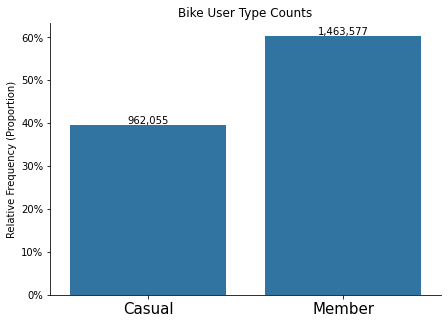

```python
#Choose the first tuple of RGB colors
base_color = sns.color_palette()[0]

plt.figure(figsize=[7,5])
ax = sns.countplot(data=df_clean, x='user_type', color=base_color)
plt.yticks(tick_prop*total,tick_labels)
plt.ylabel('Relative Frequency (Proportion)')
plt.xlabel('')
ax.set_xticklabels(['Casual','Member'],fontsize=15)
plt.title('Bike User Type Counts')

for i in range(user_count.shape[0]):
    count = user_count[i]
    pct = '{:,}'.format(count)
    plt.text(i,count+50000,pct,va='top',ha='center')

ax.spines['top'].set_visible(False)
ax.spines['right'].set_visible(False)
```

From the bar chart above, **Member** make up 60% of the customer users and **Casual** 40%

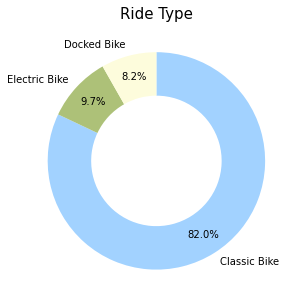

```python
ridetype_count = df_clean.rideable_type.value_counts()
labels = ridetype_count.index.str.title()

plt.figure(figsize=[10,5])
plt.pie(ridetype_count, labels=labels, colors=['#a2d2ff','#adc178', '#fdfcdc'], startangle=90, counterclock=False,
        wedgeprops={'width':0.4}, autopct='%1.1f%%', pctdistance=0.8,
        )
plt.title('Ride Type',fontsize=15);
```

The Donut chart clearly shows that the most used type of bike is the **Classic Bike** with 82% of the whole dataset

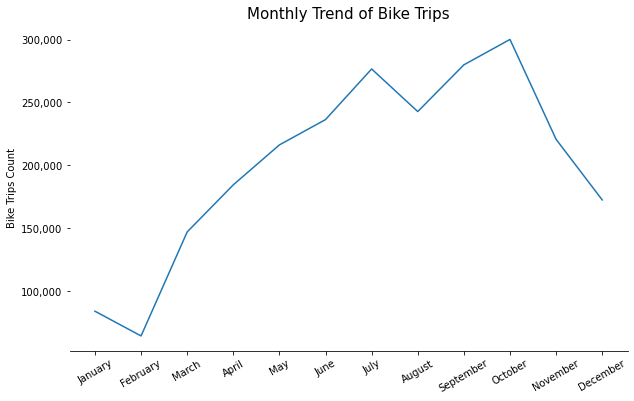

```python
# Time Series trend of bike trips across months

month_count = df_clean.started_month_name.value_counts().reindex(ordinal_var_dict['started_month_name'])

fig = plt.figure(figsize=[10,6])
ax = sns.lineplot(x=month_count.index.values, y=month_count, color=base_color)
plt.xticks(rotation=30)
plt.ylabel('Bike Trips Count')
plt.title('Monthly Trend of Bike Trips',fontsize=15)

ax.spines['top'].set_visible(False)
ax.spines['right'].set_visible(False)
ax.spines['left'].set_visible(False)
# add commas to ytick numbers
ax.get_yaxis().set_major_formatter(mpl.ticker.StrMethodFormatter('{x:,.0f}'));
```

There is an increasing number of bike trips starting in Spring (March). There was little decrease trend in August as the average temperature during that Summer period tends to be high. The highest number of trips was in October during the Fall, which is the driest season of the year, so users don't have to worry about rain spoiling their trip, unlike in Summer. There was a large decrease during the Winter season as it tends to be cold during that period coupled with snowfall.

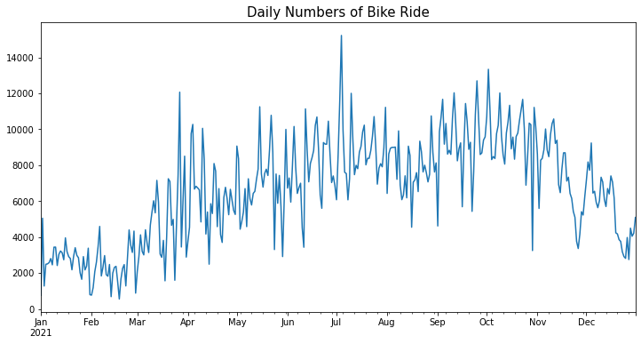

```python
# Numbers of daily bike trips trend

# creating a copy of cleaned dataframe
daily = df_clean.copy()
#setting 'started_at' column to index
daily.set_index('started_at', inplace=True)


plt.figure(figsize=[12,6])
#using resampling method to get the number of trips per day
# by using ride_id as the unique identifier count
daily['ride_id'].resample('D').size().plot(kind='line')
plt.title('Daily Numbers of Bike Ride', fontsize=15)
plt.xlabel('');
```

```python
daily['ride_id'].resample('D').size().sort_values(ascending=False)[:1]
```

```
started_at
2021-07-04    15222
Name: ride_id, dtype: int64
```

From the line chart, the highest number of bike trips per day was on the **4th of July**, which is a federal holiday in the United States commemorating the Declaration of Independence.

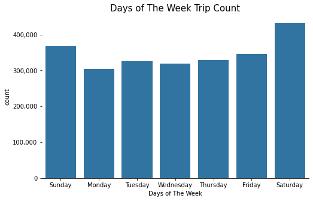

```python
#Days of the week bike trip count

plt.figure(figsize=[8,5])
ax = sns.countplot(data=df_clean, x='started_weekday', color=base_color)
plt.xlabel('Days of The Week')
plt.title('Days of The Week Trip Count',fontsize=15)

ax.spines['top'].set_visible(False)
ax.spines['right'].set_visible(False)
ax.spines['left'].set_visible(False)
ax.get_yaxis().set_major_formatter(mpl.ticker.StrMethodFormatter('{x:,.0f}'));
```

There are more bike trips during the weekend (Saturday & Sunday) compare to weekdays

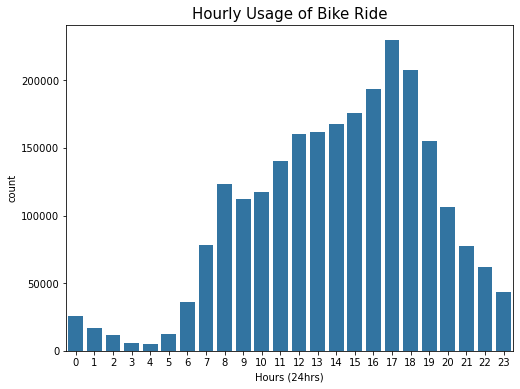

```python
# Hourly use of bike system

plt.figure(figsize=[8,6])
sns.countplot(data=df_clean, x='started_hour', color=base_color)
plt.xlabel('Hours (24hrs)')
plt.title('Hourly Usage of Bike Ride',fontsize=15);
```

The distribution is unimodal with an increasing number of bike rides from 8 am up till 5 pm which is the peak of the plot, and then a decrease in the bike trips at night time.

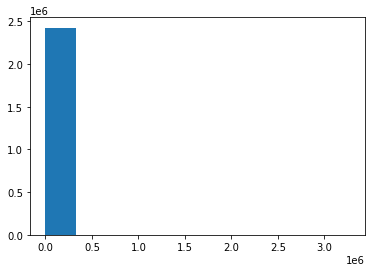

```python
# duration distribution
plt.hist(data=df_clean, x='duration_sec');
```

Since there are outliers in the `duration_sec` column, a transformation of the values will be ideal to display the duration distribution

```python
np.cbrt(df_clean.duration_sec.describe())
```

```
count    134.361539
mean      11.204743
std       23.654249
min        3.936497
25%        7.611663
50%        9.117793
75%       10.958521
max      148.464755
Name: duration_sec, dtype: float64
```

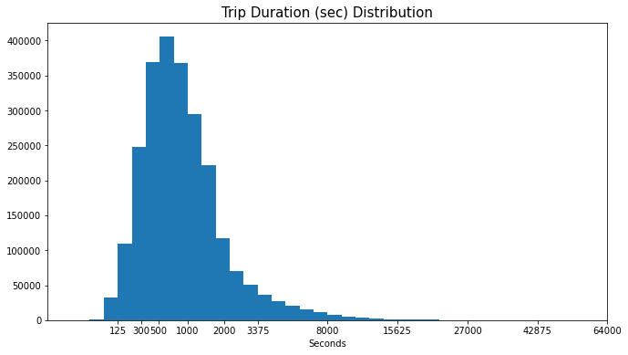

```python
# creating a cube root function
def cube_root(x, inverse=False):
    if not inverse:
        return np.cbrt(x)
    else:
        return x**3

plt.figure(figsize=[11,6])
#setting bins range
bins_edge = np.arange(3,148+1,1)
plt.hist(df_clean['duration_sec'].apply(cube_root), bins=bins_edge, color=base_color)
plt.xlim(0,40)
tick = [125, 300,500, 1000, 2000, 3375, 8000, 15625, 27000, 42875, 64000]
plt.xticks(cube_root(np.array(tick)), tick)
plt.xlabel('Seconds')
plt.title('Trip Duration (sec) Distribution',fontsize=15);
```

The distribution is right skewed with the highest distributions between 500(8 minutes) & 900(15 minutes) seconds ride durations.

**Station Analysis**

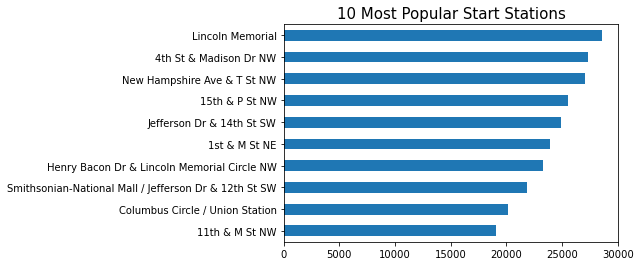

```python
# Top 10 Most Start Station location

top10_startname = df_clean.start_station_name.value_counts()[:10].sort_values()
top10_startname.plot(kind='barh', color=base_color)
plt.title('10 Most Popular Start Stations', fontsize=15);
```

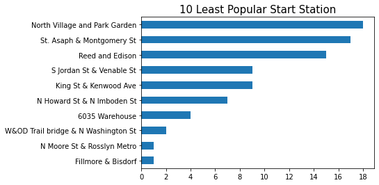

```python
# Bottom 10 Start station

bottom10 = df_clean.start_station_name.value_counts(ascending=True)[:10]
bottom10.plot(kind='barh', color=base_color)
plt.xticks(np.arange(0,20,2))
plt.title('10 Least Popular Start Station', fontsize=15);
```

For End Station

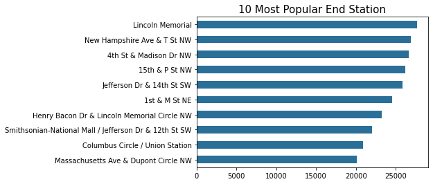

```python
# Top 10 popular end startion

top_end = df_clean.end_station_name.value_counts()[:10].sort_values()
top_end.plot(kind='barh', color='#2a6f97')
plt.title('10 Most Popular End Station', fontsize=15);
```

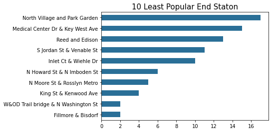

```python
# least popular end station
bottom_end = df_clean.end_station_name.value_counts(ascending=True)[:10]
bottom_end.plot(kind='barh', color='#2a6f97')
plt.title('10 Least Popular End Staton', fontsize=15);
```

### Discuss the distribution(s) of your variable(s) of interest. Were there any unusual points? Did you need to perform any transformations?

The trip duration(sec) variable took on a large range of values, and in some cases, some trips lasted for more than 24 hours. so I looked at the data using a Cube Root transform. Under the transformation, the data looked unimodally skewed to the right, with one peak between 500 and 900 seconds.

### Of the features you investigated, were there any unusual distributions? Did you perform any operations on the data to tidy, adjust, or change the form of the data? If so, why did you do this?

- There were unusual records in the trip duration(sec). Some durations were having a negative time difference between start time and end time.
- There were also cases of a trip duration of fewer than 60 seconds with the same start and end station name location. This might be a result of potentially false starts or users trying to re-dock a bike to ensure it's secure.

Above two cases were removed from the dataframe to move forward

# Bivariate Exploration

Start by checking for number of user type across months of the year

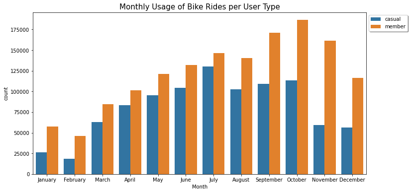

```python
plt.figure(figsize=[12,6])
sns.countplot(data=df_clean, x='started_month_name', hue='user_type')
plt.legend(loc = 2, bbox_to_anchor = (1.0, 1), shadow=True)
plt.title('Monthly Usage of Bike Rides per User Type',fontsize=15)
plt.xlabel('Month');
```

There are more numbers of **member** users bike ride compared to **casual** users across the months of the year.

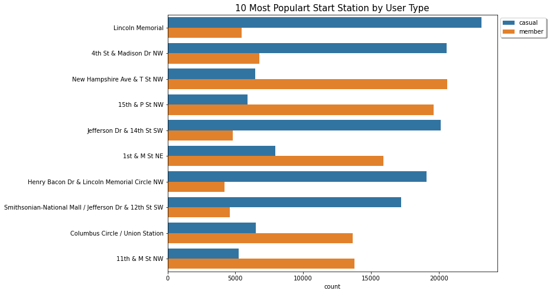

```python
# we look at user type across 10 most popular start name location

#filtering dataframe for only 10 most popular start name
start_10station = df_clean.loc[df_clean['start_station_name'].isin(top10_startname.index.values)]

plt.figure(figsize=[10,8])
# using countplot
sns.countplot(data=start_10station, y='start_station_name', hue='user_type', order=top10_startname.index.values[::-1])
plt.ylabel('')
plt.legend(loc = 2, bbox_to_anchor = (1.0, 1), shadow=True)
plt.title('10 Most Populart Start Station by User Type', fontsize=15);
```

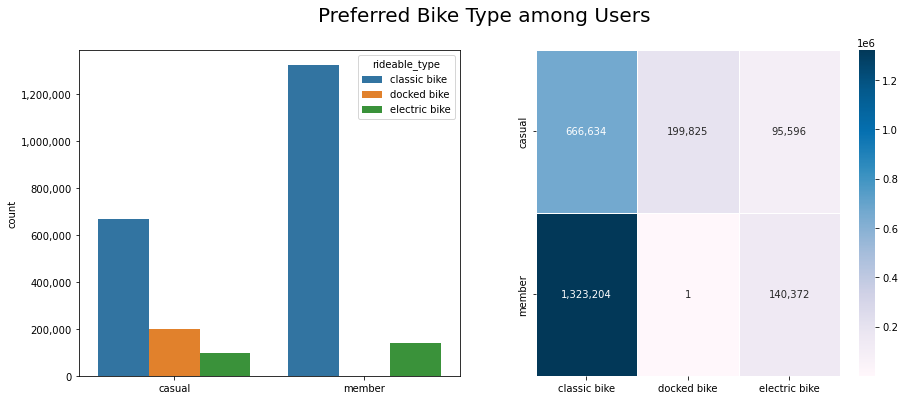

```python
plt.figure(figsize=[15,6])
plt.subplot(1,2,1)
ax = sns.countplot(data=df_clean, x='user_type', hue='rideable_type')
ax.set(xlabel='')
ax.get_yaxis().set_major_formatter(mpl.ticker.StrMethodFormatter('{x:,.0f}'));

#heatmap plot to the right
plt.subplot(1,2,2)

user_ride_count = df_clean.groupby(['user_type','rideable_type']).size()
#create as dataframe by reseting index
user_ride_df = user_ride_count.reset_index(name='count')
#pivot dataframe
user_ride_df = user_ride_df.pivot(index='user_type', columns='rideable_type', values='count')

ax = sns.heatmap(user_ride_df,fmt=',',annot=True, linewidths=.5, cmap='PuBu')
ax.set(xlabel='', ylabel='')

plt.suptitle('Preferred Bike Type among Users',fontsize=20);
```

It appears that classic bike is preferred most among both users. Interestingly, docked bike is used once by a member users and electric bike are the second most used. But for casual users, docked bike is the second most used followed by electric bike.

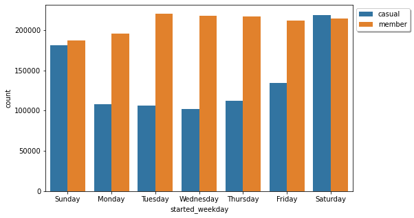

```python
# Days of the week ride count by user type

plt.figure(figsize=[8,5])
sns.countplot(data=df_clean, x='started_weekday', hue='user_type')
plt.legend(loc = 2, bbox_to_anchor = (1.0, 1), shadow=True);
```

There are more member and less casual users during weekdays (Mon - Fri).

Let look at the average trip duration across *User Type* and *Ride Type*

- **Note**: Since mean is effected too heavily by outliers, *Median* will be use to compute the average trip duration throughout the analysis

```
  user_type  Avg trip duration
0    casual             1146.0
1    member              601.0

   rideable_type  Avg trip duration
0   classic bike              702.0
1    docked bike             1754.0
2  electric bike              787.0
```

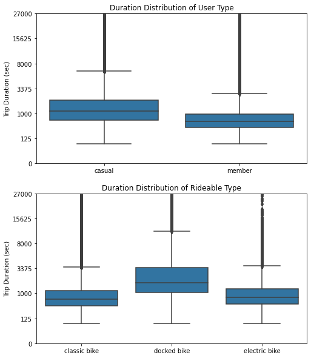

```python
#Boxplot will be use to show the median trip duration btw each categories

col = ['user_type', 'rideable_type']
plt.figure(figsize=[8,10])

for i in range(len(col)):
    ax = plt.subplot(2,1,i+1)
    sns.boxplot(x=df_clean[col[i]], y=df_clean['duration_sec'].apply(cube_root), color=base_color)
    ax.set_ylim(0,30)
    ax.set(ylabel='Trip Duration (sec)', xlabel='')
    ax.title.set_text('Duration Distribution of {}'.format(col[i].replace('_',' ').title()))
    tick = [0,5,10,15,20,25,30]
    plt.yticks(tick, cube_root(np.array(tick),inverse=True));

    print(df_clean.groupby([col[i]])['duration_sec'].median().reset_index(name='Avg trip duration'),'\n')
```

There are longer average trip duration of casual users about 1200seconds (20 minutes ) compare to member with an average of 600seconds (10 minutes), which is about half the average trip duration of casual users. And for Ride Type, there are more average lengths of duration of docked bike, having average of 1700seconds ( 29minutes). Compare to classic bike and electric bike having almost the same average length duration 700seconds (11 minutes).

Next, we see how average length of duration trips differs among Months, Weekday and Hours

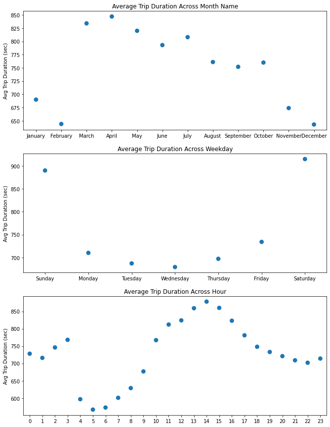

```python
cols = ['started_month_name','started_weekday', 'started_hour']
plt.figure(figsize=[11,15])
for i in range(len(cols)):
    ax = plt.subplot(3,1,i+1)
    sns.pointplot(x=df_clean[cols[i]], y=df_clean['duration_sec'], estimator=np.median, ci=None, linestyles='')
    ax.set(xlabel='', ylabel='Avg Trip Duration (sec)')
    ax.title.set_text('Average Trip Duration Across {}'.format(cols[i][8:].replace('_',' ').title()));
```

- **Months** : The highest average trip duration was in March and April and then a subsequent decreasing average trip duration in the following months of the year.
- **Weekday** : There are more average number of trips duration in the weekends (Saturday & Sunday) about 900sec (15 minutes) compare to weekdays (Monday to Friday) which is about 700sec ( 10 minutes)
- **Hours** : Although they are less number of bike rides in the early hours of the day, the avg duration between 0 and 03 hours is around 700 - 800 seconds. There is an increasing number of average trip duration from 05 hours up to the peak of the plot at 14 hours with more than 800 seconds average trip duration. And then a decreasing average duration from 15 hours to 23hours of the day.

Are there any variation of preferred Bike Type across hours of the day

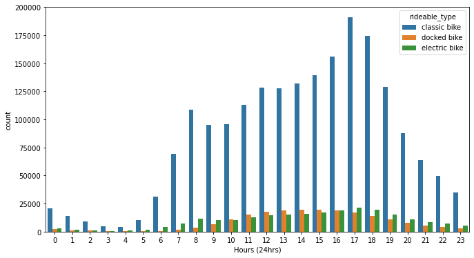

```python
plt.figure(figsize=[11,6])
sns.countplot(data=df_clean, x='started_hour', hue='rideable_type')
plt.xlabel('Hours (24hrs)');
```

The plot shows **Classic bike** greatly is preferred across the hours of the day.

### Talk about some of the relationships you observed in this part of the investigation. How did the feature(s) of interest vary with other features in the dataset?

- There are more Member users across the months of the year. This could mean that most Members are commuters. The only month in which the number of Casual users came close to Members was in July, as this period is considered the peak time for tourists to visit the country and also the month of independence of the country.
- Classic bike type is the most preferred among all users
- There are longer trip durations during the weekends compare to weekdays.

### Did you observe any interesting relationships between the other features (not the main feature(s) of interest)?

- There are longer trip duration between Casual users compare to Member.
- Docked Bike is associated with longer trip duration compare to the other type of bikes.

# Multivariate Exploration

We first look at the distribution of trip duration of different bike ride among user type

```python
# create a new column of transformed duration
df_clean['duration_cbrt'] = df_clean['duration_sec'].apply(cube_root)
```

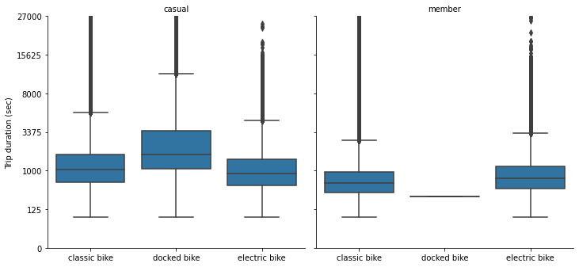

```python
g = sns.FacetGrid(data = df_clean, col = 'user_type', height = 5, ylim=(0,30))
g.map(sns.boxplot, 'rideable_type', 'duration_cbrt',
      order=['classic bike', 'docked bike', 'electric bike'])
g.set_titles('{col_name}')
ticks = np.arange(0,35,5)
g.set(ylabel='Trip duration (sec)', xlabel='',
      yticks=ticks,
      yticklabels=cube_root(ticks,inverse=True));
```

From the multivariate boxplot above, the highest average trip duration among ride types of **casual** users is the docked bike. which means that docked bike is associated with longer average durations among Casual users. And for **member** users, electric bike has a bit higher average trip duration compare to classic bike even if classic bike is the most preferred bike among all users. docked bike has a thin box plot because from the heatmap in the bivariate plot, only one member user used a docked bike in the dataset.

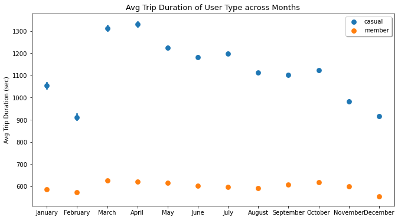

```python
plt.figure(figsize=[11,6])
sns.pointplot(data=df_clean, x='started_month_name', y='duration_sec', hue='user_type',
              estimator=np.median,
             linestyles='')
plt.ylabel('Avg Trip Duration (sec)')
plt.xlabel('')
plt.title('Avg Trip Duration of User Type across Months', fontsize=13)
plt.legend(shadow=True);
```

There is a consistent average trip duration among members which could mean that most of the members are commuters (travels some distance to work regularly). For Casual users there is varying average trip durations, this shows that they are mostly tourists.

Now we see look at what days of the week and time each user type are active

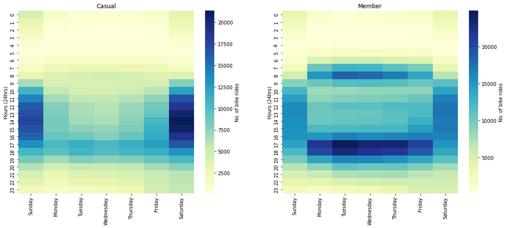

```python
users = ['casual', 'member']
plt.figure(figsize=[18,7])
for i in range(len(users)):
    plt.subplot(1,2,i+1)
    user = df_clean.loc[df_clean['user_type'] == users[i]].groupby(['started_weekday', 'started_hour'])['ride_id'].size().reset_index(name='count')
    user = user.pivot(index='started_hour', columns='started_weekday', values='count')
    ax = sns.heatmap(user, cmap='YlGnBu', cbar_kws={'label':'No. of bike rides'})
    ax.set(xlabel='', ylabel='Hours (24hrs)', title=users[i].capitalize())
```

The heatmap below depicts users activity and behaviour over the days of the week and time.

**Member**

- Users are active during commute hours (7-8 am and 5-7 pm) and every so often during lunch hours of weekdays (Mon - Fri) and are less active on the weekend.
- There is more activity during the late evening (5-7 pm) of the weekdays and early hours (7-8 am), and this could mean that there is more use of the bike on way back from work compared to in the early morning hours where a user might be running late and decides to take the bus.

**Casual**

- Users are more active during the weekend from 9 am to 7 pm and very less active during the weekday. Although occasionally active during the late evening (5 pm - 7 pm) of all days of the week which could mean an evening bike ride stroll.

### Talk about some of the relationships you observed in this part of the investigation. Were there features that strengthened each other in terms of looking at your feature(s) of interest?

The multivariate exploration showed the distinctive relationship between user's average trip durations on all bike types and usage by users at different times. There was a consistent average trip duration of Member users across the months of the year unlike casual which is double the duration of Members on average. Plotting a heatmap of each user type when bikes are high in demand throughout each hour of the day on each day of the week shed new light on the customer's behavior. Members are most active during the weekdays (Mon - Fri) at commute hours of the day and less active on the weekend. Casual users are most active during the weekends and less active during the late evening of all the days of the week.

### Were there any interesting or surprising interactions between features?

The interesting interaction was finding out the activities of each user by days of the week and month unlike the days of the week ride count by users in the bivariate plot. And findings show that they are longer average trip durations between causal than member users.